# Beating the Odds

Countries that live longer than their income predicts

Shaleen Debeila, Rebeccah Kapsekei, Lutendo Mulea, Morné Magerman, Limpo Shawa

## Everyone lives longer, but gaps remain

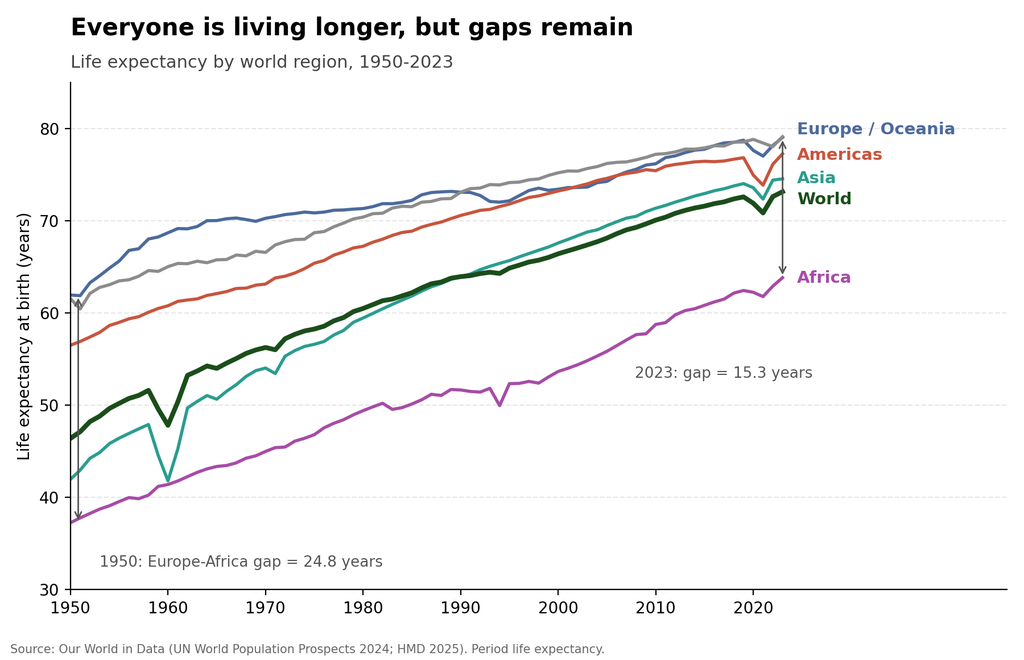

*Life expectancy is rising everywhere, but not equally. What explains the gaps?*

Source: Our World in Data (UN WPP), 1950 to 2023

## At the same income, life expectancy can differ by 20 years

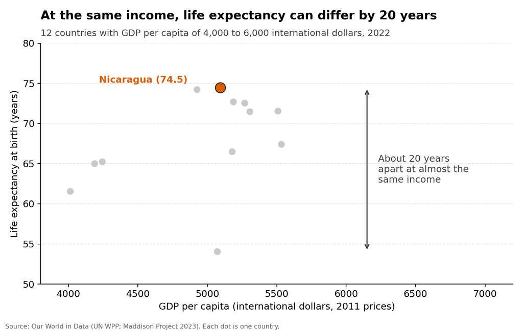

*So income is not the whole story. How much does it explain?*

Source: Our World in Data (UN WPP; Maddison Project 2023), 2022

## Income accounts for much of the variation

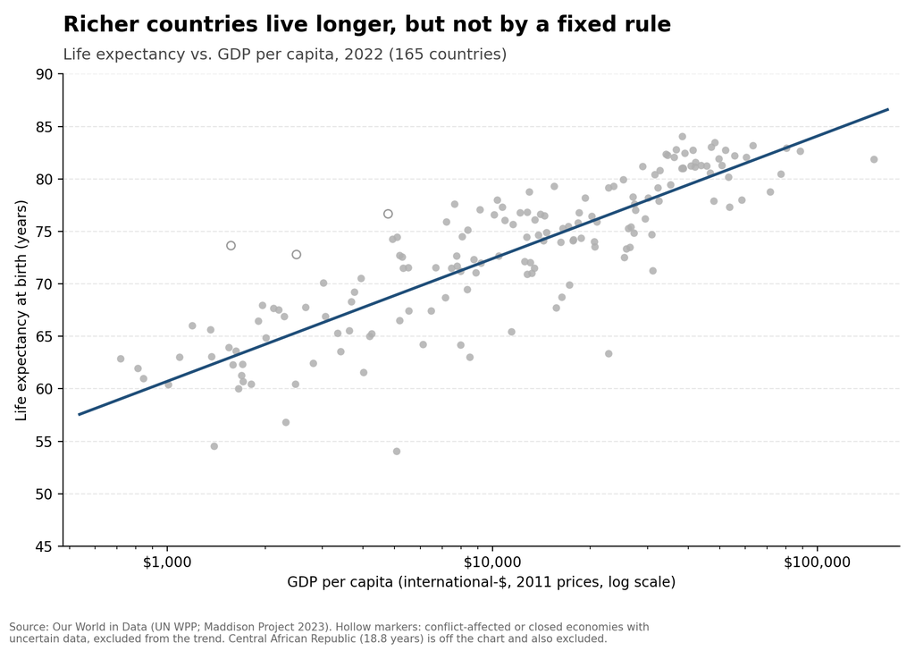

*Most countries follow the trend. A few sit far above it.*

Source: Our World in Data (UN WPP; Maddison Project 2023), 2022

## Five countries live longer than income predicts

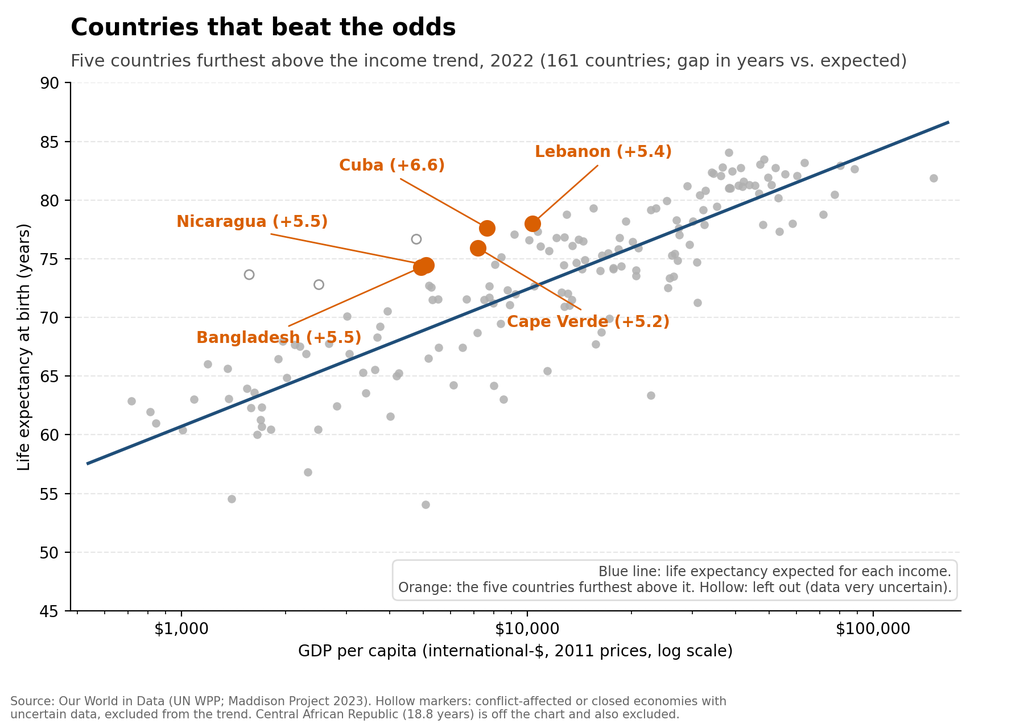

*Cuba, Nicaragua, Bangladesh, Lebanon and Cape Verde stand out. How large are their gaps?*

Source: Our World in Data (UN WPP; Maddison Project 2023), 2022

## The gap is observed minus predicted life expectancy

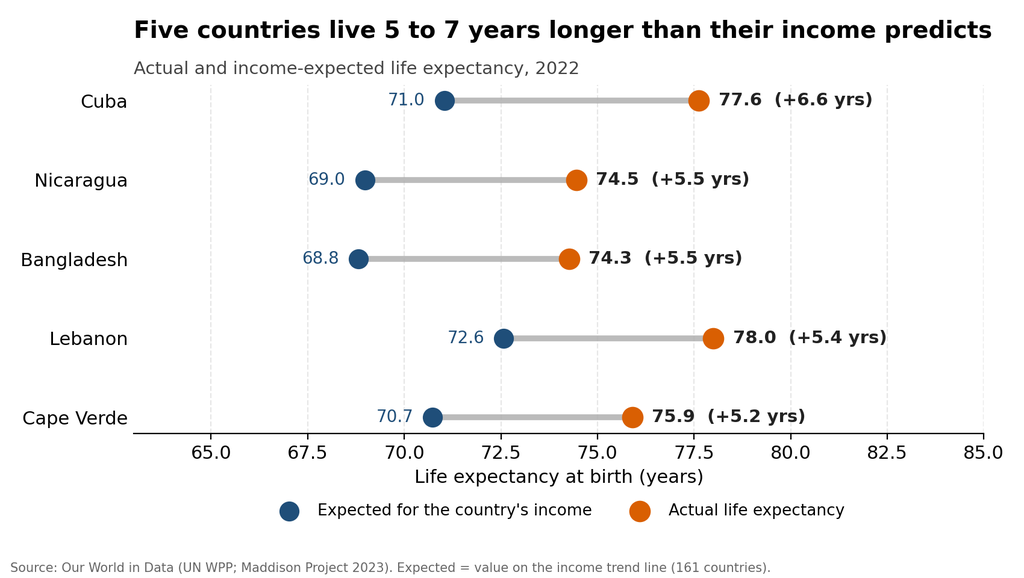

*The difference between the observed and model-predicted values defines “beating the odds.”*

Source: Our World in Data (UN WPP; Maddison Project 2023), 2022

## Large positive gaps are uncommon

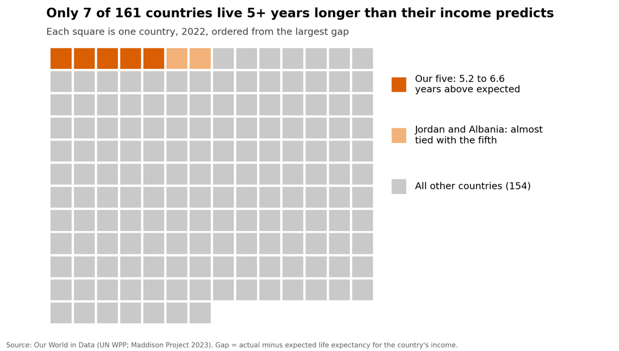

*Did these countries always do well, or did they catch up?*

Source: Our World in Data (UN WPP; Maddison Project 2023), 2022

## The five countries followed different trajectories

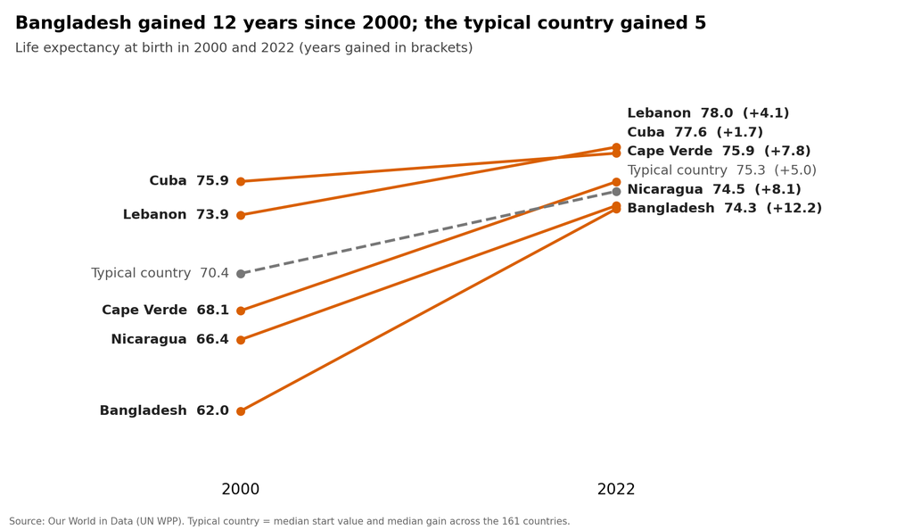

*Is healthcare spending the reason?*

Source: Our World in Data (UN WPP), 2000 to 2022

## Healthcare spending alone cannot explain the pattern

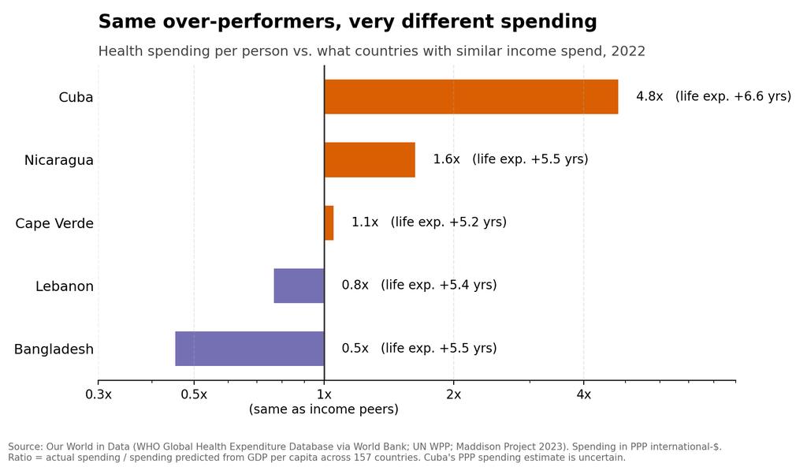

*If not spending alone, what else could help?*

Source: Our World in Data (WHO via World Bank; Maddison Project 2023), 2022

## Child survival and sanitation offer partial clues

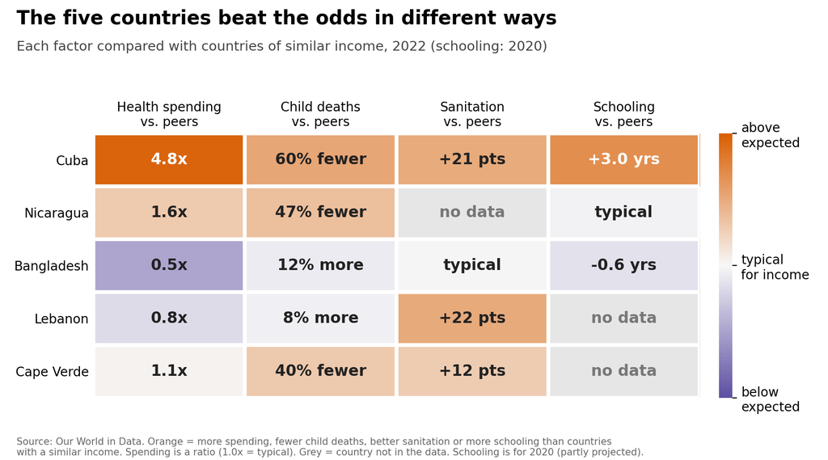

*What about inequality and schooling?*

Source: Our World in Data (UN IGME; WHO/UNICEF JMP; World Bank), latest year available

## Inequality and schooling show weak associations

- Income inequality (Gini): a very weak link to the gap, and recent data for only two of the five
- Years of schooling: a weak link; the 2020 values are partly projected

*So what is the overall picture?*

Source: Our World in Data (World Bank PIP; Barro and Lee)

## Income matters, but it is not destiny

- Wealth matters, but it does not decide how long people live
- The exceptions are starting points for questions, not proof of what works
- These are associations, not causes; one year of data; some estimates are uncertain
- Next: look closer at individual countries and at the factors we could not test

## Sources and interpretation notes

- Our World in Data: life expectancy (UN World Population Prospects), GDP per capita (Maddison Project 2023)
- Our World in Data: health spending (WHO / World Bank), child mortality (UN IGME), sanitation (WHO/UNICEF JMP)
- Our World in Data: inequality (World Bank PIP), schooling (Barro and Lee)
- Main cross-sectional comparison: 2022; other indicators use their stated years or latest available values
- The fitted income trend and observed–predicted gaps describe **associations, not causal effects**